[figure not shown]

# Taller iniciación con Dash

En este taller guiado vas a crear tu primera aplicación en Dash. Desplegarás un dashboard en local como si de una página web se tratase. Vas a utilizar la base de datos de Aplicaciones Android, donde tienes todo el listado de apps del Play Store, con su ranting, cantidad de reviews, descargas, tamaño...

Empezarás tu *Hola Mundo* creando unas primeras gráficas, después filtros y configurarás su interacción con las gráficas.

Te dejo el [enlace a la página oficial de la documentación.](https://dash.plotly.com/)

## Instalación

La instalación de Dash se realiza como cualquier otro paquete de Python, abriendo un terminal y escribiendo el comando:

```
pip install dash
```

## Introducción

Las aplicaciones Dash se componen de dos partes. Por un lado estará el `layout`, que describe cómo es la aplicación. Y por otro lado la interactividad entre los componentes de la app.

Además, cada elemento de la app es un componente de Dash. Los componentes los puedes encontrar en las librerías [`dash_core_components`](https://dash.plotly.com/dash-core-components) y [`dash_html_components`](https://dash.plotly.com/dash-html-components) (componentes puros HTML). [Puedes crear los tuyos propios](https://github.com/plotly/dash-component-boilerplate) mediante JaveScript o React.js.

## Entorno

Una app de Dash es una página web. Se programa en Python, pero después el propio Dash crea por debajo el rederizado en HTML, para que podamos visualizar e interactuar con la app desde un navegador. Por tanto, no deja de ser un servicio que está corriendo en nuestro ordenador local(de momento), al que accederemos desde el navegador.

Tendrás que programar un script de Python que por conveniencia se llama `app.py`, y dejar corriendo ese script, como si fuese un servidor. Una vez está corriendo, realizaremos consultas a ese servicio a través del navegador.

**NOTA**: Tienes que programar un script (`.py`). No te vale un Notebook de Jupyter.

## Creación proyecto

Crea un proyecto en Pycharm (o en IDE que estés usando), vacío, y añade un script que se llame `app.py`.

[figure not shown]

## Primera app

Vamos a hacer nuestro primero *Hola Mundo* en Dash. Para ello copia el siguiente código en el script `app.py`, y corre el script (NO correr línea a línea). Veamos qué significa este código:

- **Importación** de módulos de Dash
- **Estilos**: Estamos utilizando una plantilla de estilo css para nuestra app.
- **Lectura de datos**: leemos el CSV de apps de Android en un dataframe
- **fig**: antes de meternos en el layout de la app, dejamos declarada la gráfica que mostraremos luego
- **app.layout**: Aquí dentro va toda la app. Es un arbol de componentes. Si te fijas, consta de un `html.Div`, y dentro una lista de componentes (`children`).
- **Componentes**: Una cabecera grande, un subtítulo y el gráfico. Son **declarativos**, puedes describir los componentes a través de sus atributos.
- **main**: es el ejecutable del script. En este punto cambiaremos las configuraciones de la ejecución en el servidor. De momento no tocamos nada

```
# visit http://127.0.0.1:8050/ in your web browser.

import dash
import dash_core_components as dcc
import dash_html_components as html
import plotly.express as px
import pandas as pd

external_stylesheets = ['https://codepen.io/chriddyp/pen/bWLwgP.css']

app = dash.Dash(__name__, external_stylesheets=external_stylesheets)

df = pd.read_csv("data/googleplaystore.csv")

fig = px.histogram(df, x="Rating", range_x=[0.8, 5.2])

app.layout = html.Div(children=[
    html.H1(children='Dashboard aplicaciones Android'),

    html.Div(children='''
        Primera app de aprendizaje con Dash
    '''),

    dcc.Graph(
        id='example-graph',
        figure=fig
    )
])

if __name__ == '__main__':
    app.run_server(debug=True)
```

[figure not shown]

Fíjate que estás ejecutando el script, y éste no acaba nunca, se queda ahi "colgado". Es justo lo que queremos. Acabas de desplegar un servicio web en tu ordenador local. Vete al navegador y accede a la dirección que te indica. En el caso de la imagen es en `http://127.0.0.1:8050/`.

En este momento estás accediendo a una página web, cuyo servidor está corriendo en local. Siempre puedes dejar de ejecutarlo mediante el botón de parada del IDE.

Te tiene que aparecer lo siguiente en el navegador:

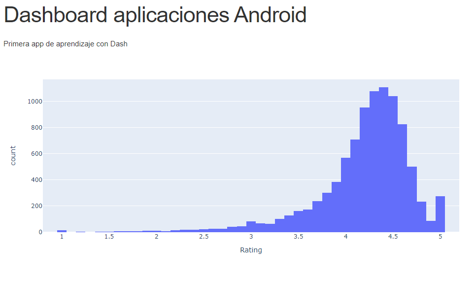

## Hot-Reloading

Se trata de una funcionalidad de Dash que permite modificar la app en código, y que se actualice automáticamente (tarda unos segundos) en el navegador. Muy útil ya que no tenemos que parar el servicio y volver a ejecutarlo para visualizar los cambios.

Estando en ejecución la app, prueba a cambiar la cabecera, y a continuación refresca el navegador.

## Estilos de componentes

Los componentes tienen el atributo de estilo, donde podremos modificar el color de la letra, del fondo o tamaño del texto. Funciona por tags, como HTML. Dentro del estilo hay unos atributos (textAlign, color...) que podrás modificar.

Prueba a crear otro sript `app2.py` con el siguiente código, ejecútalo y visualiza el output en el navegador.

```
# visit http://127.0.0.1:8050/ in your web browser.

import dash
import dash_core_components as dcc
import dash_html_components as html
import plotly.express as px
import pandas as pd

external_stylesheets = ['https://codepen.io/chriddyp/pen/bWLwgP.css']

app = dash.Dash(__name__, external_stylesheets=external_stylesheets)
colors = {
    'background': '#111111',
    'text': '#7FDBFF'
}

df = pd.read_csv("data/googleplaystore.csv")

fig = px.histogram(df, x="Rating", range_x=[0.8, 5.2])
fig.update_layout(
    plot_bgcolor=colors['background'],
    paper_bgcolor=colors['background'],
    font_color=colors['text']
)

app.layout = html.Div(
    style={'backgroundColor': colors['background']},
    children=[
    html.H1(children='Dashboard aplicaciones Android',
            style={
                'textAlign': 'center',
                'color': colors['text']
            }
            ),

    html.Div(children='''
                Primera app de aprendizaje con Dash
            ''',
             style={
                 'textAlign': 'center',
                 'color': colors['text']
             }
             ),

    dcc.Graph(
        id='example-graph',
        figure=fig
    )
])

if __name__ == '__main__':
    app.run_server(debug=True)
```

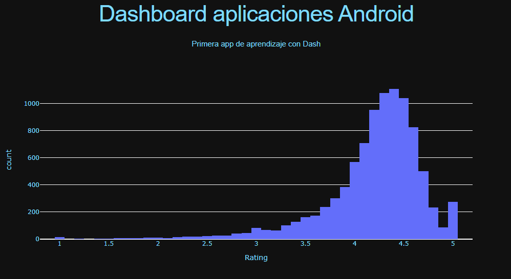

## Graph

Dentro de los `dash_core_components`, tienes `Graph`, que es el encargado de renderizar gráficas interactivas utilizando la librería de `Plotly`. El argumento figure que utiliza `Graph` es el mismo que utilizábamos con `Plotly`.

**Olvida los estilos del apartado anterior, y retoma la primera app para crear otra nueva.** Veámos cómo son las distribuciones del rating por categoría de app.

```
# visit http://127.0.0.1:8050/ in your web browser.

import dash
import dash_core_components as dcc
import dash_html_components as html
import plotly.express as px
import pandas as pd

external_stylesheets = ['https://codepen.io/chriddyp/pen/bWLwgP.css']

app = dash.Dash(__name__, external_stylesheets=external_stylesheets)

df = pd.read_csv("data/googleplaystore.csv")

fig = px.histogram(df, x="Rating", range_x=[0.8, 5.2])

fig2 = px.box(df, x="Category", y="Rating", color="Category", range_y=[0.8, 5.2])

app.layout = html.Div(children=[
    html.H1(children='Dashboard aplicaciones Android'),

    html.Div(children='''
        Primera app de aprendizaje con Dash
    '''),

    dcc.Graph(
        id='example-graph',
        figure=fig
    ),
    dcc.Graph(
        id='example-graph-box',
        figure=fig2
    )
])

if __name__ == '__main__':
    app.run_server(debug=True)
```

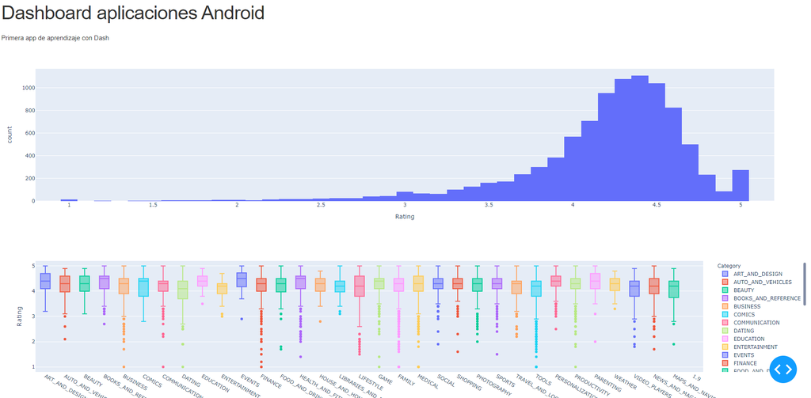

## Core components

Dash tiene una gran cantidad de componentes propios, como menus desplegables, radio buttons, gráficos, entre otros. También, como en el caso de los componentes HTML, son declarativos, por lo que tendrás que ir configurando sus atributos. [Aquí tienes todos los componentes disponibles](https://dash.plotly.com/dash-core-components)

Vamos a empezar a colocar algún filtro en nuestro dashboard. En concreto, un selector desplegable con multiopción, que nos permita seleccionar entre las apps gratuitas, o las de pago. Insertamos el siguiente componente entre los títulos y las gráficas:

```
dcc.Dropdown(
        id='id_free_paid',
        options=[
            {'label': 'Free', 'value': 'Free'},
            {'label': 'Paid', 'value': 'Paid'}
        ],
        value=['Free', 'Paid'],
        multi=True
    )
```

De momento tenemos una caja que tiene un menu desplegable donde seleccionamos `Free` y/o `Paid`, y no hace nada más. La inteligencia del filtrado la introduciremos con un **callback**.

## Callbacks

Son funciones que se llaman automáticamente cuando cambia algún componente de la app. ¿Para qué se usa esto? Para poner botones, interacciones del usuario con la web y filtrar las gráficas en función de esas interaccciones.

Como ya tenemos un selector, ahora vamos a vincularlo con las otras dos gráficas usando un callback. Coloca este codigo entre el layout y el main. Tienes que importar los siguients componentes:

```
from dash.dependencies import Input, Output, State
```

```
@app.callback(
    Output('example-graph', 'figure'),
    Output('example-graph-box', 'figure'),
    [Input('id_free_paid', 'value')])
def update_graphs_selector(selected_type):
    filtered_df = df[df["Type"].isin(selected_type)]

    fig = px.histogram(filtered_df, x="Rating", range_x=[0.8, 5.2])
    fig2 = px.box(filtered_df, x="Category", y="Rating", color="Category", range_y=[0.8, 5.2])

    fig.update_layout()
    fig2.update_layout()

    return fig, fig2
```

Lo que va antes de la función es qué inputs hay y sobre qué outputs van a afectar. Para vincularlos utilizamos sus `id`s. El argumento de la función `update_graphs_selector` es el input del selector (una lista). Con esa lista filtramos los datos del dataframe, creamos figuras nuevas con estos datos y refrescamos el front con esas figuras.

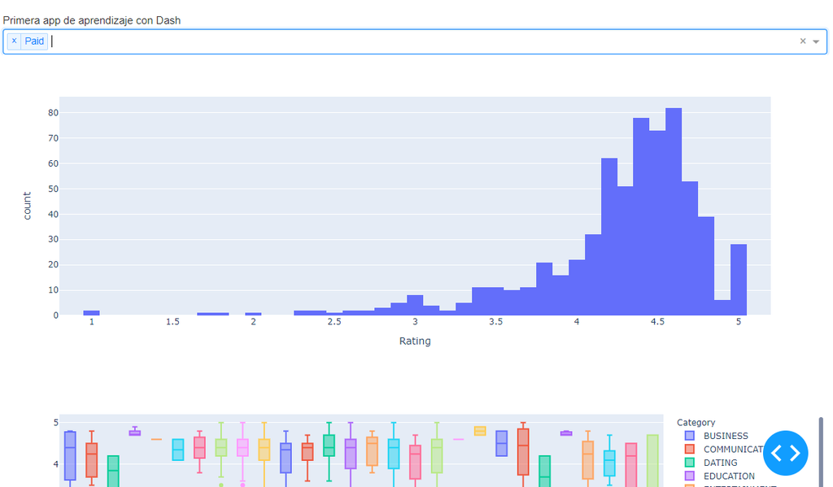

## Posicionamiento en layout

Hasta ahora hemos estado creando gráficas y apilándolas verticalmente. Pero, ¿y si queremos aplicarlas horizontamente? Ir haciendo cajas verticales y horizontales con diferentes componentes, tal y como se hace en HTML. Para ello, nos vamos a apoyar en el paquete `dash_bootstrap_components`. Tienes que instalarlo mediante:

```
pip install dash_bootstrap_components
```

Estos componentes son *responsive*, por lo que se adaptan dependiendo del tamaño de la pantalla, por lo que dará igual si la página se abre desde un móvil, tablet u ordenador. [Te recomiendo que leas la documentación](https://dash-bootstrap-components.opensource.faculty.ai/docs/components/layout/) para que comprendas mejor cómo colocar tus componentes en el layout. Para alinear tus componentes como quieras, tendrás que jugar con:

- dbc.Container
- dbc.Row
- dbc.Column

El siguiente ejemplo está compuesto de:

1. Dos Rows para los títulos
2. Otro Row en el que irán dos columnas:
   - Un gráfico que ocupa todo el alto de la fila
   - Un Col con dos gráficos
3. Un Row con tres Cols, en cada uno un gráfico de diferente color.

**NOTA**: Además de instalar el nuevo paquete, fíjate que cuando se crea el objeto `app`, utilizamos un elemento del nuevo módulo instalado `dash_bootstrap_components`

```
# visit http://127.0.0.1:8050/ in your web browser.

import dash
import dash_core_components as dcc
import dash_html_components as html
import plotly.express as px
import pandas as pd
import dash_bootstrap_components as dbc

external_stylesheets = ['https://codepen.io/chriddyp/pen/bWLwgP.css']

app = dash.Dash(__name__, external_stylesheets=[dbc.themes.GRID, external_stylesheets])

df = pd.read_csv("data/googleplaystore.csv")

fig_blue = px.histogram(df, x="Rating", range_x=[0.8, 5.2], color_discrete_sequence=['blue'])
fig_red = px.histogram(df, x="Rating", range_x=[0.8, 5.2], color_discrete_sequence=['red'])
fig_orange = px.histogram(df, x="Rating", range_x=[0.8, 5.2], color_discrete_sequence=['orange'])
fig_black = px.histogram(df, x="Rating", range_x=[0.8, 5.2], color_discrete_sequence=['black'])
fig_green = px.histogram(df, x="Rating", range_x=[0.8, 5.2], color_discrete_sequence=['green'])

fig_box = px.box(df, x="Category", y="Rating", range_y=[0.8, 5.2])
fig_box2 = px.box(df, x="Category", y="Rating", color="Category", range_y=[0.8, 5.2])


app.layout = html.Div(
        [
            dbc.Row(dbc.Col(html.H1(children='Dashboard aplicaciones Android'))),
            dbc.Row(dbc.Col(html.Div(children='Primera app de aprendizaje con Dash'))),
            dbc.Row(
                [
                    dbc.Col(dcc.Graph(
                        id='graph-blue',
                        figure=fig_blue,
                        style={'height': '100%'}
                     )),

                    dbc.Col([
                            dbc.Row(dcc.Graph(
                                id='graph-box',
                                figure=fig_box
                            )),
                            dbc.Row(dcc.Graph(
                                id='graph-box2',
                                figure=fig_box2
                            ))]
                    )
                ]
            ),

            dbc.Row(
                [
                    dbc.Col(dcc.Graph(
                        id='graph-orange',
                        figure=fig_orange
                    )),
                    dbc.Col(dcc.Graph(
                        id='graph-black',
                        figure=fig_black
                    )),
                    dbc.Col(dcc.Graph(
                        id='graph-green',
                        figure=fig_green
                    ))
                ]
            )
        ]
)



if __name__ == '__main__':
    app.run_server(debug=True)
```

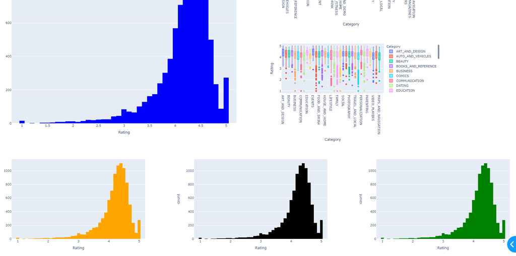

**¡Ya tienes tu primera aplicacion Dash!** A lo largo del notebook te he ido dejando enlaces a la documentación que te resultarán de gran utilidad. Además Dash dispone de una [galería de dashboards](https://dash-gallery.plotly.host/Portal/) publicados por los propios usuarios de Dash, por si quieres coger ideas :)

Conocimientos de HTML y CSS previos vienen muy bien para manejarse con esta librería. Te recomiendo que si no es el caso, y tienes que empezezar una app de cero, vayas al enlace con la galería de dashboards y te descargues o imites una de las plantillas de los dashboards, así ahorrarás bastante trabajo.